# Desarrollo Laboratorio 2 - Análisis de Datos

Mauricio Vargas S.

16 de agosto de 2015

## Pregunta 1

Considere el vector

```r
x <- c(0.18, -1.54, 0.42, 0.95)
```

y los ponderadores

```r
w <- c(2, 1, 3, 1)
```

Encuentre el valor de $\mu$ que minimiza la ecuación de mínimos cuadrados $\Sigma_{i=1}^n w_i(x_i-\mu)^2$. Hágalo de las siguientes formas:

1. Algebraicamente
2. En Excel (el archivo con los datos es [laboratorio2-pregunta1](http://pachamaltese.github.io/econometria/laboratorio2/laboratorio2-pregunta1.xlsx))
3. En R

### Desarrollo

#### Algebraicamente

Sea $S = \displaystyle\Sigma_{i=1}^n w_i(x_i-\mu)^2$

$S = \displaystyle\Sigma_{i=1}^n w_i(x_i^2-2x_i\mu+\mu^2)$

$S = \displaystyle\Sigma_{i=1}^n w_ix_i^2 -2\mu\displaystyle\Sigma_{i=1}^n w_ix_i +\mu^2\displaystyle\Sigma_{i=1}^n w_i$

$\displaystyle \frac{dS}{d\mu} = 0 \Leftrightarrow -2\displaystyle\Sigma_{i=1}^n w_ix_i +2\mu^* \displaystyle\Sigma_{i=1}^n w_i = 0$

$\displaystyle \frac{dS}{d\mu} = 0 \Leftrightarrow \mu^* = \frac{\Sigma_{i=1}^n w_ix_i}{\Sigma_{i=1}^n w_i}$

#### Excel

Ver archivo laboratorio2-desarrollo-pregunta1.xlsx

#### R

El promedio ponderado se obtiene con el siguiente comando

```r
weighted.mean(x, w) # 0.1471
```

```
## [1] 0.1471429
```

## Pregunta 2

Considere los vectores

```r
y <- c(12.96, 5.15, 9.07, 5.36, 13.68, 11.86, 22.49, 6.54, 17.98, 11.43, 9.73, 5.44, 5.73, 8.84, 3.78, 4.74, 4.62, 3.92, 5.2)
x1 <- c(2, 6, 3, 5, 3, 3, 0, 4, 2, 4, 5, 7, 5, 4, 9, 6, 7, 7, 7)
x2 <- c(57.5, 83.2, 67, 92.7, 40.7, 79.8, 23.5, 81, 64.4, 65.8, 69.3, 72.9, 107.5, 92.1, 86.1, 89.4, 93.3, 107.1, 116.9)
```

Obtenga el vector $\beta = (\beta_0,\beta_1,\beta_2)$ usando la ecuación $\beta = (X'X)^{-1}(X'Y)$. Resuelva usando algebra matricial.

### Desarrollo

```r
#Vemos la dimensión de y
length(y)
```

```
## [1] 19
```

```r
#Convertimos los vectores x1 y x2 a matrices de 19x1
X1 <- matrix(x1, ncol=1, nrow=19)
X2 <- matrix(x2, ncol=1, nrow=19)

#Hay que crear una matriz X0 de 19x1 para estimar un modelo con constante
X0 <- matrix(c(rep(1,19)), ncol=1, nrow=19)

#Armamos la matriz X a partir de X0,X1,X2
X <- cbind(X0, X1, X2)

#Obtenemos X'X e invertimos
#Sea A = (X'X)^-1
A <- solve(t(X) %*% X)

#Obtenemos X'Y
#Sea B = X'Y
Y <- matrix(y, ncol=1, nrow=19)
B <- t(X) %*% Y

#Obtenemos ß
beta <- A %*% B
beta
```

```
##             [,1]
## [1,] 22.22048141
## [2,] -1.40916785
## [3,] -0.08606443
```

## Pregunta 3

Considere los siguientes vectores de datos

```r
x <- c(0.8, 0.47, 0.51, 0.73, 0.36, 0.58, 0.57, 0.85, 0.44, 0.42)
y <- c(1.39, 0.72, 1.55, 0.48, 1.19, -1.59, 1.23, -0.65, 1.49, 0.05)
```

Estime una regresión desde el origen y obtenga la pendiente considerando $y$ como la variable dependiente y $x$ como la variable independiente. ¿Cómo cambia su resultado si estima un modelo con constante?

### Desarrollo

Regresión tal que $\beta_0$ pasa por el origen

```r
fit.sc <- lm(y ~ x - 1) #modelo sin constante
summary(fit.sc) # 0.8263
```

```
##
## Call:
## lm(formula = y ~ x - 1)
##
## Residuals:
##     Min      1Q  Median      3Q     Max
## -2.0692 -0.2536  0.5303  0.8592  1.1286
##
## Coefficients:
##   Estimate Std. Error t value Pr(>|t|)
## x   0.8263     0.5817   1.421    0.189
##
## Residual standard error: 1.094 on 9 degrees of freedom
## Multiple R-squared:  0.1831, Adjusted R-squared:  0.09238
## F-statistic: 2.018 on 1 and 9 DF,  p-value: 0.1892
```

```r
fit.c <- lm(y ~ x) #modelo con constante
summary(fit.c) #-1.713
```

```
##
## Call:
## lm(formula = y ~ x)
##
## Residuals:
##     Min      1Q  Median      3Q     Max
## -2.1640 -0.5818  0.2010  0.6669  1.1928
##
## Coefficients:
##             Estimate Std. Error t value Pr(>|t|)
## (Intercept)    1.567      1.252   1.252    0.246
## x             -1.713      2.105  -0.814    0.439
##
## Residual standard error: 1.061 on 8 degrees of freedom
## Multiple R-squared:  0.07642,    Adjusted R-squared:  -0.03903
## F-statistic: 0.662 on 1 and 8 DF,  p-value: 0.4394
```

## Pregunta 4

Usando la base de datos mtcars estime un modelo que considere mpg como variable independiente y la weight como variable independiente. Almacene la pendiente del modelo en memoria con el nombre “beta.1”.

### Desarrollo

```r
data(mtcars) #para cargar la librería en memoria
fit <- lm(mpg ~ wt, mtcars)
summary(fit) # -5.3445
```

```
##
## Call:
## lm(formula = mpg ~ wt, data = mtcars)
##
## Residuals:
##     Min      1Q  Median      3Q     Max
## -4.5432 -2.3647 -0.1252  1.4096  6.8727
##
## Coefficients:
##             Estimate Std. Error t value Pr(>|t|)
## (Intercept)  37.2851     1.8776  19.858  < 2e-16 ***
## wt           -5.3445     0.5591  -9.559 1.29e-10 ***
## ---
## Signif. codes:  0 '***' 0.001 '**' 0.01 '*' 0.05 '.' 0.1 ' ' 1
##
## Residual standard error: 3.046 on 30 degrees of freedom
## Multiple R-squared:  0.7528, Adjusted R-squared:  0.7446
## F-statistic: 91.38 on 1 and 30 DF,  p-value: 1.294e-10
```

```r
beta.1 <- fit$coefficients[2]
```

## Pregunta 5

A partir del archivo Excel utilizado en el Laboratorio 1 (laboratorio1.xlsx) obtenga las mismas regresiones (con y sin constante) utilizando R. Para esto siga los siguientes pasos:

1. Definir variables en memoria y cargar librerías
- Definir el directorio de trabajo.
- Instalar una librería que permita leer archivos XLSX. Usaremos XLConnect cuya documentación se puede ver en https://cran.r-project.org/web/packages/XLConnect/XLConnect.pdf.
- Cargar la librería XLConnect.
- Leer el archivo del Laboratorio 1.
- Asignar nombres **simples** a las columnas ($y$, $x_1$, $x_2$).
2. Haga un gráfico de cada variable explicativa sobre la explicada ¿Hay correlación entre ellas?
- Instalar y cargar en memoria ggplot (librería para graficar)
- Graficar $y$ versus $x_1$ e $y$ versus $x_2$.
- Ver la correlación entre las variables.
3. Calcule el estimador de los parámetros.
- Hacer una regresión sin constante.
- Hacer una regresión con constante

### Desarrollo

```r
#1. Definir variables en memoria y cargar librerías
    #Definir el directorio de trabajo
    dir <- "/Users/pacha/pachamaltese.github.io/econometria/laboratorio1"

    #Instalar una librería que permita leer archivos XLSX
    #install.packages("XLConnect")

    #Cargar la librería XLConnect
    library(XLConnect)
    #Leer el archivo del Laboratorio 1
    file <- paste0(dir,"/laboratorio1.xlsx")
    data <- readWorksheetFromFile(file, sheet = "Hoja1", region = "A2:C20", header = FALSE)
    data
```

```
##     Col1 Col2  Col3
## 1  12.96    2  57.5
## 2   5.15    6  83.2
## 3   9.07    3  67.0
## 4   5.36    5  92.7
## 5  13.68    3  40.7
## 6  11.86    3  79.8
## 7  22.49    0  23.5
## 8   6.54    4  81.0
## 9  17.98    2  64.4
## 10 11.43    4  65.8
## 11  9.73    5  69.3
## 12  5.44    7  72.9
## 13  5.73    5 107.5
## 14  8.84    4  92.1
## 15  3.78    9  86.1
## 16  4.74    6  89.4
## 17  4.62    7  93.3
## 18  3.92    7 107.1
## 19  5.20    7 116.9
```

```r
    #Asignar nombres simples a las columnas
    colnames(data) <- c("y", "x1", "x2")
    data
```

```
##        y x1    x2
## 1  12.96  2  57.5
## 2   5.15  6  83.2
## 3   9.07  3  67.0
## 4   5.36  5  92.7
## 5  13.68  3  40.7
## 6  11.86  3  79.8
## 7  22.49  0  23.5
## 8   6.54  4  81.0
## 9  17.98  2  64.4
## 10 11.43  4  65.8
## 11  9.73  5  69.3
## 12  5.44  7  72.9
## 13  5.73  5 107.5
## 14  8.84  4  92.1
## 15  3.78  9  86.1
## 16  4.74  6  89.4
## 17  4.62  7  93.3
## 18  3.92  7 107.1
## 19  5.20  7 116.9
```

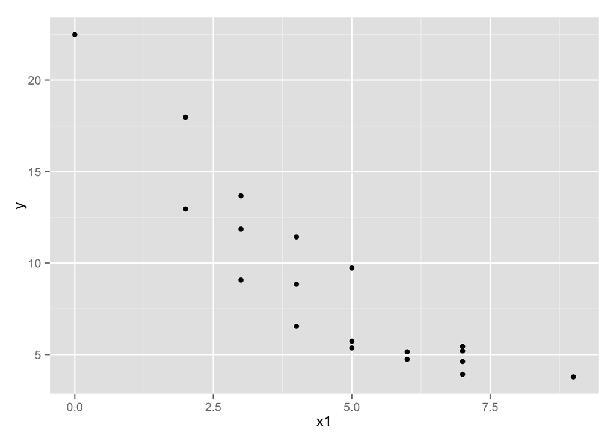

```r
#2. Haga un gráfico de cada variable explicativa sobre la explicada ¿Hay correlación entre ellas?

    #Instalar y cargar en memoria ggplot (librería para graficar)
    #install.packages("ggplot2")
    library(ggplot2)

    #Graficar y versus x1 e y versus x2
    qplot(x1, y, data=data)
```

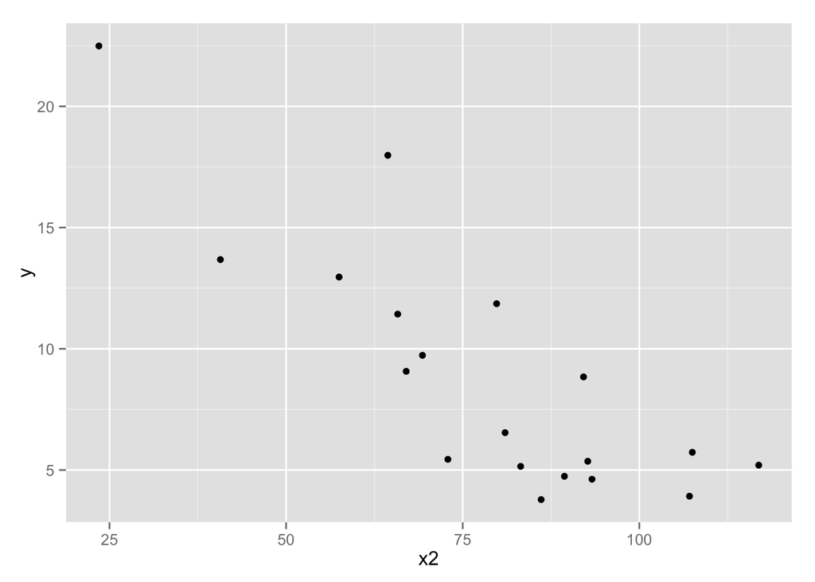

```r
    qplot(x2, y, data=data)
```

```r
    #Ver la correlación entre las variables
    cor(data)
```

```
##             y         x1         x2
## y   1.0000000 -0.8911151 -0.8284953
## x1 -0.8911151  1.0000000  0.7270866
## x2 -0.8284953  0.7270866  1.0000000
```

```r
#Calcule el estimador de los parámetros

    #Hacer una correlación sin constante
    regression_nocons <- lm(y ~ x1 + x2 -1, data=data)
    summary(regression_nocons)
```

```
##
## Call:
## lm(formula = y ~ x1 + x2 - 1, data = data)
##
## Residuals:
##     Min      1Q  Median      3Q     Max
## -7.1186 -2.7070  0.8237  4.8973 17.4404
##
## Coefficients:
##    Estimate Std. Error t value Pr(>|t|)
## x1  -2.0501     1.0054  -2.039  0.05731 .
## x2   0.2149     0.0637   3.373  0.00361 **
## ---
## Signif. codes:  0 '***' 0.001 '**' 0.01 '*' 0.05 '.' 0.1 ' ' 1
##
## Residual standard error: 6.638 on 17 degrees of freedom
## Multiple R-squared:  0.6201, Adjusted R-squared:  0.5754
## F-statistic: 13.87 on 2 and 17 DF,  p-value: 0.0002674
```

```r
    #Hacer una regresión con constante
    regression_cons <- lm(y ~ x1 + x2, data=data)
    summary(regression_cons)
```

```
##
## Call:
## lm(formula = y ~ x1 + x2, data = data)
##
## Residuals:
##     Min      1Q  Median      3Q     Max
## -3.1567 -1.3931  0.1827  0.7581  4.1204
##
## Coefficients:
##             Estimate Std. Error t value Pr(>|t|)
## (Intercept) 22.22048    1.71538  12.954 6.74e-10 ***
## x1          -1.40917    0.30976  -4.549 0.000328 ***
## x2          -0.08606    0.03025  -2.845 0.011696 *
## ---
## Signif. codes:  0 '***' 0.001 '**' 0.01 '*' 0.05 '.' 0.1 ' ' 1
##
## Residual standard error: 2.019 on 16 degrees of freedom
## Multiple R-squared:  0.8633, Adjusted R-squared:  0.8462
## F-statistic: 50.51 on 2 and 16 DF,  p-value: 1.222e-07
```